# IODS course project

Milja von Lerber

8 helmikuuta 2017

This is the Introduction to open data science course in Helsinki unversity.

My personal feelings about Introduction to open data science-course: my feelings about this course are quite mixed, though positive. I am not sure how well I will do, but I will do my best, you can be certain about that!

Milja

a link to my IODS repository: https://github.com/miljavon/IODS-project

# Chapter 2

## Wrangling

First I tried wrangling data with R. I read the data online to RStudio and started working with it. First, I explored the dimensions of the data, wich proved to be about 180 observations and 60 variables.

After that I molded the data in a form that was easy to analyze. I combined all the variables which described the same things. Lastly, I only kept seven columns: age, attitude, points, strategic learning, deep learning, surface learning and gender.

Then I was ready to have the directory changed from default to IODS-project and save the data in a much prettier form.

## Analyzing

First I had to install some packages I could analyze the data with. After that I was good to go and make perhaps the most impressive graph I´ve ever made in my life:

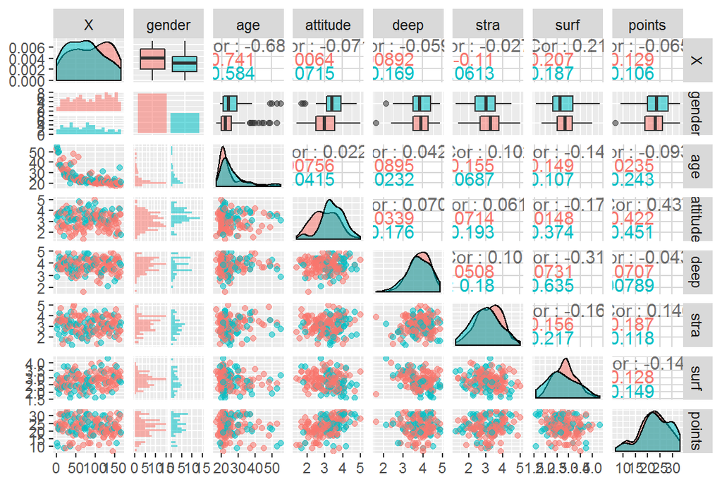

From the graph you can clearly see the connections of the variables.

After that I printed the summaries of each variable. I am not going to print them here, but I’m going to tell briefly, what I found out.

There were significantly more females than males. The age ranged from very young (17) to 55. The median was 22 though, which wasn’t surprising.The overall attitude seems to have been modestly positive: about 3,5 out of five. Surface learning waas siginificantly lower than the other kinds of learning.

Then I had to analyze, which variables had the most effect on points. I concluded that attitude, surface learning and strategic learning were most important and I created a statistical model out of it.

```r
library(ggplot2)
library(GGally)
learning2014 <- read.table("learning2014", header = TRUE, sep = ",")
my_model2 <- lm(points ~ attitude + stra + surf, data = learning2014)
summary(my_model2)
```

```
##
## Call:
## lm(formula = points ~ attitude + stra + surf, data = learning2014)
##
## Residuals:
##      Min       1Q   Median       3Q      Max
## -17.1550  -3.4346   0.5156   3.6401  10.8952
##
## Coefficients:
##             Estimate Std. Error t value Pr(>|t|)
## (Intercept)  11.0171     3.6837   2.991  0.00322 **
## attitude      3.3952     0.5741   5.913 1.93e-08 ***
## stra          0.8531     0.5416   1.575  0.11716
## surf         -0.5861     0.8014  -0.731  0.46563
## ---
## Signif. codes:  0 '***' 0.001 '**' 0.01 '*' 0.05 '.' 0.1 ' ' 1
##
## Residual standard error: 5.296 on 162 degrees of freedom
## Multiple R-squared:  0.2074, Adjusted R-squared:  0.1927
## F-statistic: 14.13 on 3 and 162 DF,  p-value: 3.156e-08
```

From the summary it is visible that the variables strategic and surface learning were not statistically significant, so I removed them from the model and made a picture of the more simple model.

```
##
## Call:
## lm(formula = points ~ attitude, data = learning2014)
##
## Residuals:
##      Min       1Q   Median       3Q      Max
## -16.9763  -3.2119   0.4339   4.1534  10.6645
##
## Coefficients:
##             Estimate Std. Error t value Pr(>|t|)
## (Intercept)  11.6372     1.8303   6.358 1.95e-09 ***
## attitude      3.5255     0.5674   6.214 4.12e-09 ***
## ---
## Signif. codes:  0 '***' 0.001 '**' 0.01 '*' 0.05 '.' 0.1 ' ' 1
##
## Residual standard error: 5.32 on 164 degrees of freedom
## Multiple R-squared:  0.1906, Adjusted R-squared:  0.1856
## F-statistic: 38.61 on 1 and 164 DF,  p-value: 4.119e-09
```

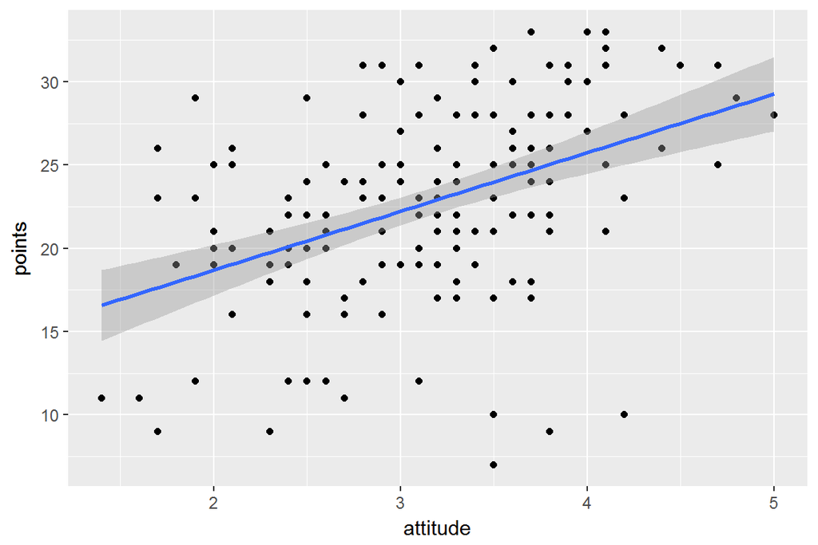

Now, with my model I can see that on average when attitude gets one unit better get the points over three units higher. The relationship has statistical significance, but is still able to explain only about 20% of the amount of points. The intercept-variable seems to be also statistically significant, but it has very little significance in real life.

# Chapter 3

Here I will show how I analyzed the data. First I will look at the names of the variables. This data is collected from students. The point is to analyze their alcohol usage.

```r
url<- "http://s3.amazonaws.com/assets.datacamp.com/production/course_2218/datasets/alc.txt"
alc <- read.table(url, sep = ",", header = TRUE)
```

Now I will choose 4 interesting variables of the data and see how it affects the amounts the students drink alcohol. I will choose sex of the students, their fathers’ level of education, their relationship status and the quality of their relationship within their families.

My personal hypothesis is that sex will have a minor effect on the amount of alcohol the students use. Men probably will drink more than women.

Whether the father is educated will have no significant relationship with overall usage of alcohol. It is probable though, that when it comes to high consumption, the father will have a lower education.

My personal hypothesis is that students with a romantic relationship won’t drink as much as the ones that don’t.

My hypothesis is as well, that the better relationships students have with their families, the less they will drink.

```r
library(tidyr)
library(dplyr)
```

```r
library(ggplot2)

alc %>% group_by(sex, high_use) %>% summarise(count = n(),father_education =mean(Fedu))
```

```
## Source: local data frame [4 x 4]
## Groups: sex [?]
##
##      sex high_use count father_education
##   <fctr>    <lgl> <int>            <dbl>
## 1      F    FALSE   157         2.496815
## 2      F     TRUE    41         2.585366
## 3      M    FALSE   113         2.646018
## 4      M     TRUE    71         2.577465
```

```r
alc %>% group_by(sex, romantic) %>% summarise(count = n(),alcohol =mean(alc_use))
```

```
## Source: local data frame [4 x 4]
## Groups: sex [?]
##
##      sex romantic count  alcohol
##   <fctr>   <fctr> <int>    <dbl>
## 1      F       no   129 1.627907
## 2      F      yes    69 1.586957
## 3      M       no   132 2.071970
## 4      M      yes    52 2.384615
```

```r
alc %>% group_by(sex, high_use) %>% summarise(count = n(),family_relationships =mean(famrel))
```

```
## Source: local data frame [4 x 4]
## Groups: sex [?]
##
##      sex high_use count family_relationships
##   <fctr>    <lgl> <int>                <dbl>
## 1      F    FALSE   157             3.917197
## 2      F     TRUE    41             3.731707
## 3      M    FALSE   113             4.150442
## 4      M     TRUE    71             3.774648
```

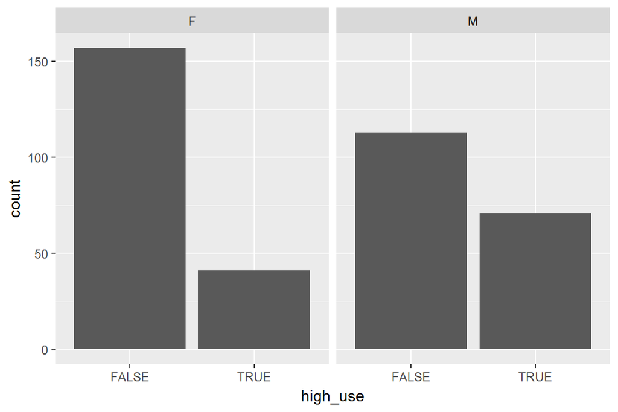

```r
g2 <- ggplot(data = alc, aes(high_use), fill = sex)
g2+geom_bar()+facet_wrap("sex")
```

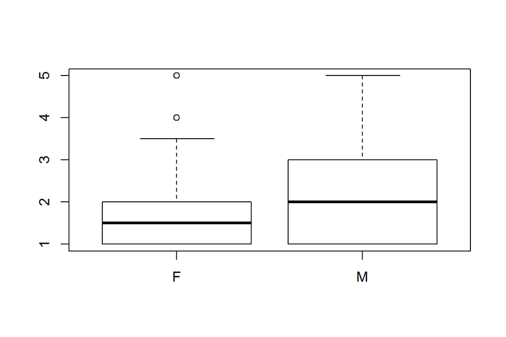

```r
boxplot(alc_use ~ sex, data = alc)
```

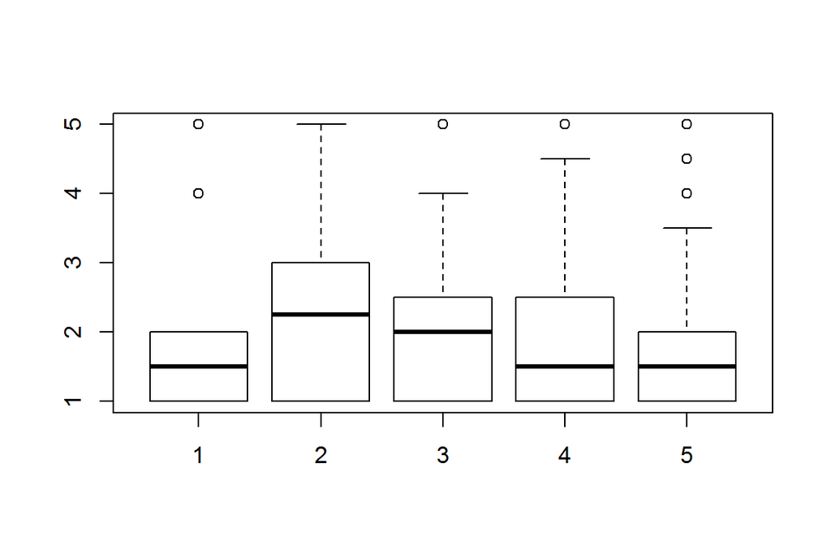

```r
boxplot(alc_use ~ famrel, data = alc)
```

From the numerical summaries as well from the data visualization one can see, that being male definately affects the amount of alcohol students drink.

From the education of father you get different results for girls and boys.For girls those who drink a lot their fathers are more educated whereas when it comes to boys, those who drink a lot have on average a father with a lower education. The differences might mean nothing though: the differences are so minor.

For romantic relationships girls with a romantic elationship drink less, but boys with a relationship drink actually more, which was surprising.This was also hardly significant.

With family relationship the difference of people who use a lot of alcohol and ones who don’t was actually very clear. People with a better relationship with their family rarely drink as much.

```r
m <- glm(high_use ~ sex + romantic+ Fedu + famrel, data = alc, family = "binomial")
summary(m)
```

```
##
## Call:
## glm(formula = high_use ~ sex + romantic + Fedu + famrel, family = "binomial",
##     data = alc)
##
## Deviance Residuals:
##     Min       1Q   Median       3Q      Max
## -1.3813  -0.8701  -0.6725   1.2144   2.0001
##
## Coefficients:
##              Estimate Std. Error z value Pr(>|z|)
## (Intercept)  0.004752   0.564678   0.008  0.99329
## sexM         0.933587   0.236726   3.944 8.02e-05 ***
## romanticyes -0.138636   0.253821  -0.546  0.58493
## Fedu         0.003135   0.105821   0.030  0.97636
## famrel      -0.344807   0.123164  -2.800  0.00512 **
## ---
## Signif. codes:  0 '***' 0.001 '**' 0.01 '*' 0.05 '.' 0.1 ' ' 1
##
## (Dispersion parameter for binomial family taken to be 1)
##
##     Null deviance: 462.21  on 381  degrees of freedom
## Residual deviance: 439.42  on 377  degrees of freedom
## AIC: 449.42
##
## Number of Fisher Scoring iterations: 4
```

Counting confidence intervals:

```r
confint(m)
```

```
##                  2.5 %     97.5 %
## (Intercept) -1.1125448  1.1097143
## sexM         0.4747631  1.4044528
## romanticyes -0.6442339  0.3532360
## Fedu        -0.2044852  0.2112038
## famrel      -0.5885247 -0.1039446
```

```r
m1 <- glm(high_use ~ sex + famrel, data = alc, family = "binomial")
probabilities <- predict(m1, type = "response")
alc <- mutate(alc, probability = probabilities)
alc <- mutate(alc, prediction = probability > 0.5)
table(high_use = alc$high_use, prediction = alc$prediction)
```

```
##         prediction
## high_use FALSE TRUE
##    FALSE   266    4
##    TRUE    104    8
```

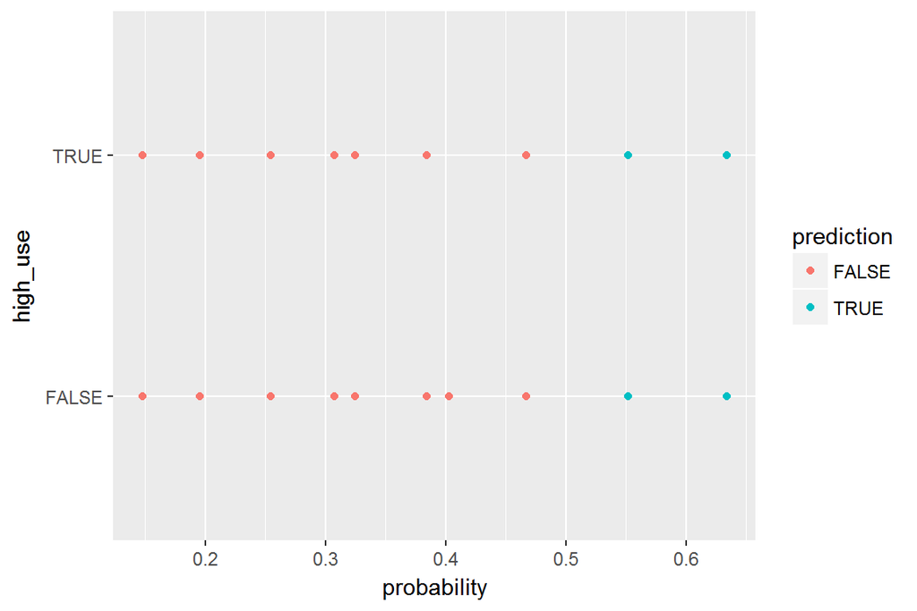

```r
g <- ggplot(alc, aes(x =probability, y = high_use, col = prediction))
g + geom_point()
```

```r
loss_func <- function(class, prob) {
  n_wrong <- abs(class - prob) > 0.5
  mean(n_wrong)
}
loss_func(class = alc$high_use, alc$probability)
```

```
## [1] 0.2827225
```

From the predictions we can see that my model is not very good: almost a third were were falsely predicted. So the prediction power of my model is not very good.

Still, compared to random guessing, my model works better (because if I were to guess, I would have about 0.5 probability to get it right).

Here I’m trying out cross validation.

```r
library(boot)
cv <- cv.glm(data = alc, cost = loss_func, glmfit = m1, 10)
cv$delta[1]
```

```
## [1] 0.2827225
```

My model sadly is not better than the example model in datacamp.

Here I will show how I analyzed the data. First I will look at the names of the variables. This data is collected from students. The point is to analyze their alcohol usage.

```r
colnames(alc)
```

```
##  [1] "school"      "sex"         "age"         "address"     "famsize"
##  [6] "Pstatus"     "Medu"        "Fedu"        "Mjob"        "Fjob"
## [11] "reason"      "nursery"     "internet"    "guardian"    "traveltime"
## [16] "studytime"   "failures"    "schoolsup"   "famsup"      "paid"
## [21] "activities"  "higher"      "romantic"    "famrel"      "freetime"
## [26] "goout"       "Dalc"        "Walc"        "health"      "absences"
## [31] "G1"          "G2"          "G3"          "alc_use"     "high_use"
## [36] "probability" "prediction"
```

Now I will choose 4 interesting variables of the data and see how it affects the amounts the students drink alcohol. I will choose sex of the students, their fathers’ level of education, their relationship status and the quality of their relationship within their families.

My personal hypothesis is that sex will have a minor effect on the amount of alcohol the students use. Men probably will drink more than women.

Whether the father is educated will have no significant relationship with overall usage of alcohol. It is probable though, that when it comes to high consumption, the father will have a lower education.

My personal hypothesis is that students with a romantic relationship won’t drink as much as the ones that don’t.

My hypothesis is as well, that the better relationships students have with their families, the less they will drink.

```r
library(tidyr)
library(dplyr)
library(ggplot2)

alc %>% group_by(sex, high_use) %>% summarise(count = n(),father_education =mean(Fedu))
```

```
## Source: local data frame [4 x 4]
## Groups: sex [?]
##
##      sex high_use count father_education
##   <fctr>    <lgl> <int>            <dbl>
## 1      F    FALSE   157         2.496815
## 2      F     TRUE    41         2.585366
## 3      M    FALSE   113         2.646018
## 4      M     TRUE    71         2.577465
```

```r
alc %>% group_by(sex, romantic) %>% summarise(count = n(),alcohol =mean(alc_use))
```

```
## Source: local data frame [4 x 4]
## Groups: sex [?]
##
##      sex romantic count  alcohol
##   <fctr>   <fctr> <int>    <dbl>
## 1      F       no   129 1.627907
## 2      F      yes    69 1.586957
## 3      M       no   132 2.071970
## 4      M      yes    52 2.384615
```

```r
alc %>% group_by(sex, high_use) %>% summarise(count = n(),family_relationships =mean(famrel))
```

```
## Source: local data frame [4 x 4]
## Groups: sex [?]
##
##      sex high_use count family_relationships
##   <fctr>    <lgl> <int>                <dbl>
## 1      F    FALSE   157             3.917197
## 2      F     TRUE    41             3.731707
## 3      M    FALSE   113             4.150442
## 4      M     TRUE    71             3.774648
```

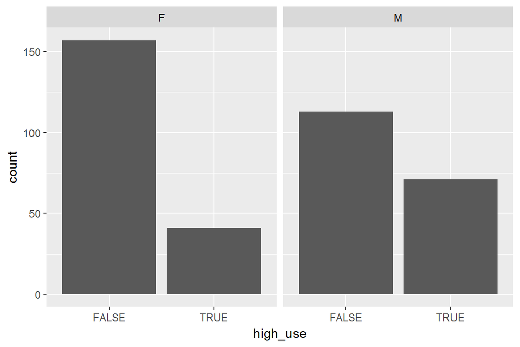

```r
g2 <- ggplot(data = alc, aes(high_use), fill = sex)
g2+geom_bar()+facet_wrap("sex")
```

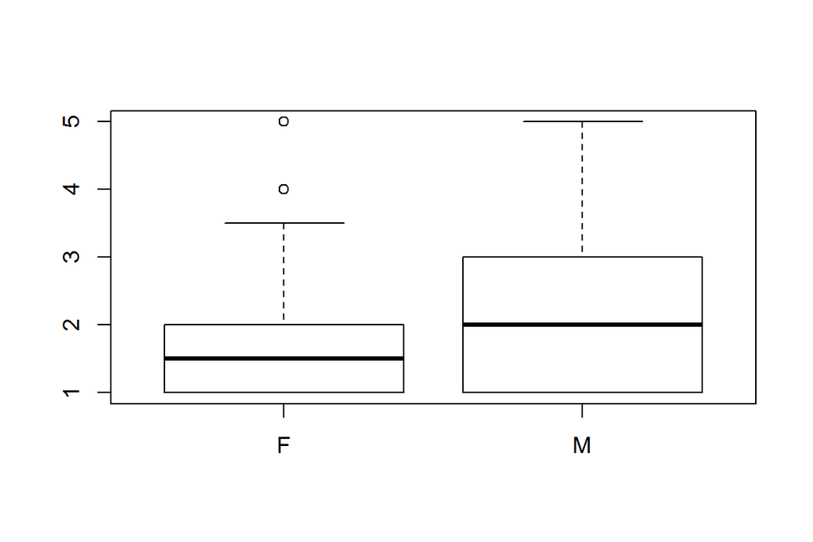

```r
boxplot(alc_use ~ sex, data = alc)
```

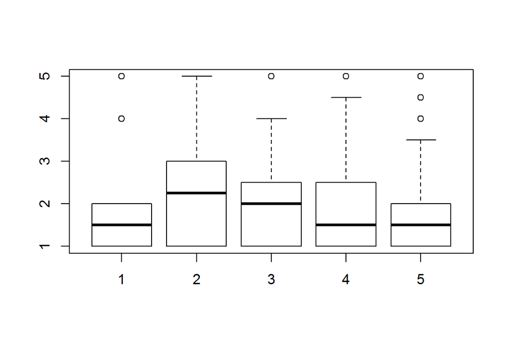

```r
boxplot(alc_use ~ famrel, data = alc)
```

From the numerical summaries as well from the data visualization one can see, that being male definately affects the amount of alcohol students drink.

From the education of father you get different results for girls and boys.For girls those who drink a lot their fathers are more educated whereas when it comes to boys, those who drink a lot have on average a father with a lower education. The differences might mean nothing though: the differences are so minor.

For romantic relationships girls with a romantic elationship drink less, but boys with a relationship drink actually more, which was surprising.This was also hardly significant.

With family relationship the difference of people who use a lot of alcohol and ones who don’t was actually very clear. People with a better relationship with their family rarely drink as much.

```r
m <- glm(high_use ~ sex + romantic+ Fedu + famrel, data = alc, family = "binomial")
summary(m)
```

```
##
## Call:
## glm(formula = high_use ~ sex + romantic + Fedu + famrel, family = "binomial",
##     data = alc)
##
## Deviance Residuals:
##     Min       1Q   Median       3Q      Max
## -1.3813  -0.8701  -0.6725   1.2144   2.0001
##
## Coefficients:
##              Estimate Std. Error z value Pr(>|z|)
## (Intercept)  0.004752   0.564678   0.008  0.99329
## sexM         0.933587   0.236726   3.944 8.02e-05 ***
## romanticyes -0.138636   0.253821  -0.546  0.58493
## Fedu         0.003135   0.105821   0.030  0.97636
## famrel      -0.344807   0.123164  -2.800  0.00512 **
## ---
## Signif. codes:  0 '***' 0.001 '**' 0.01 '*' 0.05 '.' 0.1 ' ' 1
##
## (Dispersion parameter for binomial family taken to be 1)
##
##     Null deviance: 462.21  on 381  degrees of freedom
## Residual deviance: 439.42  on 377  degrees of freedom
## AIC: 449.42
##
## Number of Fisher Scoring iterations: 4
```

Counting confidence intervals:

```r
confint(m)
```

```
##                  2.5 %     97.5 %
## (Intercept) -1.1125448  1.1097143
## sexM         0.4747631  1.4044528
## romanticyes -0.6442339  0.3532360
## Fedu        -0.2044852  0.2112038
## famrel      -0.5885247 -0.1039446
```

```r
m1 <- glm(high_use ~ sex + famrel, data = alc, family = "binomial")
probabilities <- predict(m1, type = "response")
alc <- mutate(alc, probability = probabilities)
alc <- mutate(alc, prediction = probability > 0.5)
table(high_use = alc$high_use, prediction = alc$prediction)
```

```
##         prediction
## high_use FALSE TRUE
##    FALSE   266    4
##    TRUE    104    8
```

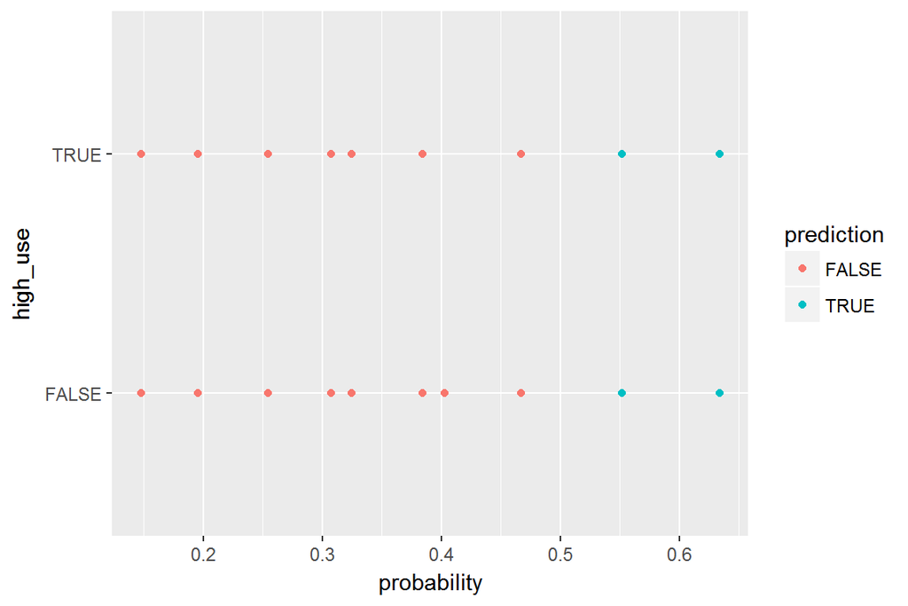

```r
g <- ggplot(alc, aes(x =probability, y = high_use, col = prediction))
g + geom_point()
```

```r
loss_func <- function(class, prob) {
  n_wrong <- abs(class - prob) > 0.5
  mean(n_wrong)
}
loss_func(class = alc$high_use, alc$probability)
```

```
## [1] 0.2827225
```

From the predictions we can see that my model is not very good: almost a third were were falsely predicted. So the prediction power of my model is not very good.

Still, compared to random guessing, my model works better (because if I were to guess, I would have about 0.5 probability to get it right).

Here I’m trying out cross validation.

```r
library(boot)
cv <- cv.glm(data = alc, cost = loss_func, glmfit = m1, 10)
cv$delta[1]
```

```
## [1] 0.2827225
```

My model sadly is not better than the example model in datacamp. I sadly had no time to do bonus excercises, because github desktop was not working properly and I had to figure that out.

# Chapter 4

In this chapter I will learn about LDA and clustering.

Accessing the Boston-dataset and eploring the structure of the data.

```r
library(MASS)
data("Boston")
str(Boston)
```

```
## 'data.frame':    506 obs. of  14 variables:
##  $ crim   : num  0.00632 0.02731 0.02729 0.03237 0.06905 ...
##  $ zn     : num  18 0 0 0 0 0 12.5 12.5 12.5 12.5 ...
##  $ indus  : num  2.31 7.07 7.07 2.18 2.18 2.18 7.87 7.87 7.87 7.87 ...
##  $ chas   : int  0 0 0 0 0 0 0 0 0 0 ...
##  $ nox    : num  0.538 0.469 0.469 0.458 0.458 0.458 0.524 0.524 0.524 0.524 ...
##  $ rm     : num  6.58 6.42 7.18 7 7.15 ...
##  $ age    : num  65.2 78.9 61.1 45.8 54.2 58.7 66.6 96.1 100 85.9 ...
##  $ dis    : num  4.09 4.97 4.97 6.06 6.06 ...
##  $ rad    : int  1 2 2 3 3 3 5 5 5 5 ...
##  $ tax    : num  296 242 242 222 222 222 311 311 311 311 ...
##  $ ptratio: num  15.3 17.8 17.8 18.7 18.7 18.7 15.2 15.2 15.2 15.2 ...
##  $ black  : num  397 397 393 395 397 ...
##  $ lstat  : num  4.98 9.14 4.03 2.94 5.33 ...
##  $ medv   : num  24 21.6 34.7 33.4 36.2 28.7 22.9 27.1 16.5 18.9 ...
```

The data has 506 observations of 14 variables. Here I will show a brief graphical overview and show some short summaries of the variables

```r
summary(Boston)
```

```
##       crim                zn             indus            chas
##  Min.   : 0.00632   Min.   :  0.00   Min.   : 0.46   Min.   :0.00000
##  1st Qu.: 0.08204   1st Qu.:  0.00   1st Qu.: 5.19   1st Qu.:0.00000
##  Median : 0.25651   Median :  0.00   Median : 9.69   Median :0.00000
##  Mean   : 3.61352   Mean   : 11.36   Mean   :11.14   Mean   :0.06917
##  3rd Qu.: 3.67708   3rd Qu.: 12.50   3rd Qu.:18.10   3rd Qu.:0.00000
##  Max.   :88.97620   Max.   :100.00   Max.   :27.74   Max.   :1.00000
##       nox               rm             age              dis
##  Min.   :0.3850   Min.   :3.561   Min.   :  2.90   Min.   : 1.130
##  1st Qu.:0.4490   1st Qu.:5.886   1st Qu.: 45.02   1st Qu.: 2.100
##  Median :0.5380   Median :6.208   Median : 77.50   Median : 3.207
##  Mean   :0.5547   Mean   :6.285   Mean   : 68.57   Mean   : 3.795
##  3rd Qu.:0.6240   3rd Qu.:6.623   3rd Qu.: 94.08   3rd Qu.: 5.188
##  Max.   :0.8710   Max.   :8.780   Max.   :100.00   Max.   :12.127
##       rad              tax           ptratio          black
##  Min.   : 1.000   Min.   :187.0   Min.   :12.60   Min.   :  0.32
##  1st Qu.: 4.000   1st Qu.:279.0   1st Qu.:17.40   1st Qu.:375.38
##  Median : 5.000   Median :330.0   Median :19.05   Median :391.44
##  Mean   : 9.549   Mean   :408.2   Mean   :18.46   Mean   :356.67
##  3rd Qu.:24.000   3rd Qu.:666.0   3rd Qu.:20.20   3rd Qu.:396.23
##  Max.   :24.000   Max.   :711.0   Max.   :22.00   Max.   :396.90
##      lstat            medv
##  Min.   : 1.73   Min.   : 5.00
##  1st Qu.: 6.95   1st Qu.:17.02
##  Median :11.36   Median :21.20
##  Mean   :12.65   Mean   :22.53
##  3rd Qu.:16.95   3rd Qu.:25.00
##  Max.   :37.97   Max.   :50.00
```

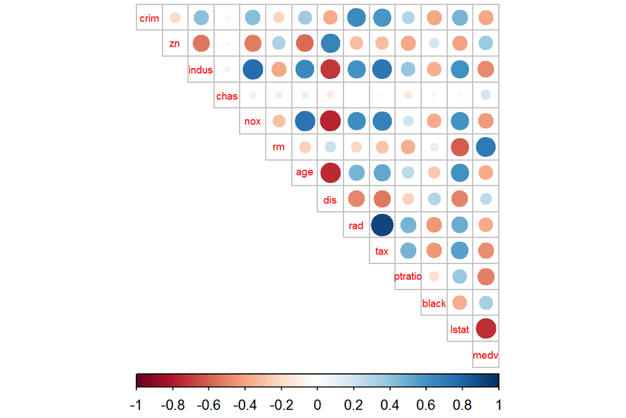

```r
cor_matrix<-cor(Boston) %>% round(digits = 2)
corrplot(cor_matrix, method="circle", type = "upper", cl.pos = "b", tl.pos = "d", tl.cex = 0.6)
```

Now we can see the summaries of the variables and a statistical overview. From the variable crime we can see, that most of the people don’t commit crime. It is a small precentage, that commits almost all of the crime in Boston. Crime seems to be positively related to index of accessibility to radial highways and full-value property-tax rate per $10,000.

The average number of rooms per dwelling seems to be around six and minimum over 3. The variable is quite evenly distributed, and it is negatively related to lower status of the population and positively related to median value of homes.

Age is negatively related to Boston employment centers. The variable age seems to be quite strange though: the majority of data comes from people that are around 70 years old.The old people seem to live in areas with a high nitrogen concentration.

Next I will scale the data and print out the summaries.

```r
boston_scaled <- scale(Boston)
summary(boston_scaled)
```

```
##       crim                 zn               indus
##  Min.   :-0.419367   Min.   :-0.48724   Min.   :-1.5563
##  1st Qu.:-0.410563   1st Qu.:-0.48724   1st Qu.:-0.8668
##  Median :-0.390280   Median :-0.48724   Median :-0.2109
##  Mean   : 0.000000   Mean   : 0.00000   Mean   : 0.0000
##  3rd Qu.: 0.007389   3rd Qu.: 0.04872   3rd Qu.: 1.0150
##  Max.   : 9.924110   Max.   : 3.80047   Max.   : 2.4202
##       chas              nox                rm               age
##  Min.   :-0.2723   Min.   :-1.4644   Min.   :-3.8764   Min.   :-2.3331
##  1st Qu.:-0.2723   1st Qu.:-0.9121   1st Qu.:-0.5681   1st Qu.:-0.8366
##  Median :-0.2723   Median :-0.1441   Median :-0.1084   Median : 0.3171
##  Mean   : 0.0000   Mean   : 0.0000   Mean   : 0.0000   Mean   : 0.0000
##  3rd Qu.:-0.2723   3rd Qu.: 0.5981   3rd Qu.: 0.4823   3rd Qu.: 0.9059
##  Max.   : 3.6648   Max.   : 2.7296   Max.   : 3.5515   Max.   : 1.1164
##       dis               rad               tax             ptratio
##  Min.   :-1.2658   Min.   :-0.9819   Min.   :-1.3127   Min.   :-2.7047
##  1st Qu.:-0.8049   1st Qu.:-0.6373   1st Qu.:-0.7668   1st Qu.:-0.4876
##  Median :-0.2790   Median :-0.5225   Median :-0.4642   Median : 0.2746
##  Mean   : 0.0000   Mean   : 0.0000   Mean   : 0.0000   Mean   : 0.0000
##  3rd Qu.: 0.6617   3rd Qu.: 1.6596   3rd Qu.: 1.5294   3rd Qu.: 0.8058
##  Max.   : 3.9566   Max.   : 1.6596   Max.   : 1.7964   Max.   : 1.6372
##      black             lstat              medv
##  Min.   :-3.9033   Min.   :-1.5296   Min.   :-1.9063
##  1st Qu.: 0.2049   1st Qu.:-0.7986   1st Qu.:-0.5989
##  Median : 0.3808   Median :-0.1811   Median :-0.1449
##  Mean   : 0.0000   Mean   : 0.0000   Mean   : 0.0000
##  3rd Qu.: 0.4332   3rd Qu.: 0.6024   3rd Qu.: 0.2683
##  Max.   : 0.4406   Max.   : 3.5453   Max.   : 2.9865
```

Now we can see the scaled variables. It can be seen how the data is now more clearly distributed and the variables can be compared with each other.

Here I create a new crime variable from the scaled dataset and divide the data to test and train sets, in which there are 80% of the data.

```r
boston_scaled<- scale(Boston)
boston_scaled<-as.data.frame(boston_scaled)
scaled_crim <- boston_scaled$crim
bins <- quantile(scaled_crim)
crime <- cut(scaled_crim, breaks = bins, include.lowest = TRUE, labels = c("low", "med_low", "med_high", "high"))
boston_scaled$crime <- crime
n <- nrow(boston_scaled)
ind <- sample(n, size = n * 0.8)
train <- boston_scaled[ind,]
test <- boston_scaled[-ind,]
```

Here I will do linear discriminant analysis to observe the data. The target variable will be crime and all the other variables will act as predictors.

```r
library(MASS)
lda.fit <- lda(crime ~ ., data = train)
lda.fit
```

```
## Call:
## lda(crime ~ ., data = train)
##
## Prior probabilities of groups:
##       low   med_low  med_high      high
## 0.2301980 0.2500000 0.2673267 0.2524752
##
## Group means:
##                crim          zn      indus          chas        nox
## low      -0.4149419  0.86569483 -0.9166907 -0.1876602454 -0.8712321
## med_low  -0.4031346 -0.09519033 -0.2635673  0.0005392655 -0.5565190
## med_high -0.2973181 -0.39830983  0.2346115  0.2380357777  0.4256511
## high      1.2116853 -0.48724019  1.0171096 -0.1565320019  1.0385448
##                   rm        age        dis        rad        tax
## low       0.36309718 -0.8407551  0.9039835 -0.7052512 -0.7184567
## med_low  -0.12468339 -0.3543977  0.3368652 -0.5600086 -0.4868307
## med_high  0.04826513  0.4514394 -0.3820305 -0.4374128 -0.3052198
## high     -0.47010105  0.8026863 -0.8505428  1.6382099  1.5141140
##             ptratio       black       lstat        medv
## low      -0.4731532  0.37426466 -0.72754293  0.41931036
## med_low  -0.1280937  0.31046966 -0.13891130  0.03185092
## med_high -0.2330810  0.09233254  0.03776953  0.12630477
## high      0.7808718 -0.90367938  0.99328555 -0.76467617
##
## Coefficients of linear discriminants:
##                 LD1          LD2         LD3
## crim     0.15148584  0.076651689 -0.13802458
## zn       0.14386921  0.600179598 -1.05833085
## indus    0.01380273 -0.197450149  0.50314632
## chas    -0.10832031 -0.133338351  0.10100918
## nox      0.38043410 -0.844925258 -1.30303329
## rm      -0.10029045 -0.095063368 -0.13983304
## age      0.28228228 -0.369245833 -0.28508569
## dis     -0.09617299 -0.234272185  0.13257596
## rad      3.45139110  0.808203133  0.09176636
## tax     -0.08278161  0.060317715  0.33586148
## ptratio  0.20003929 -0.144849658 -0.37360610
## black   -0.09824414  0.004739926  0.04633520
## lstat    0.20931249 -0.186516213  0.39994154
## medv     0.23823311 -0.463953630 -0.14825010
##
## Proportion of trace:
##    LD1    LD2    LD3
## 0.9556 0.0346 0.0098
```

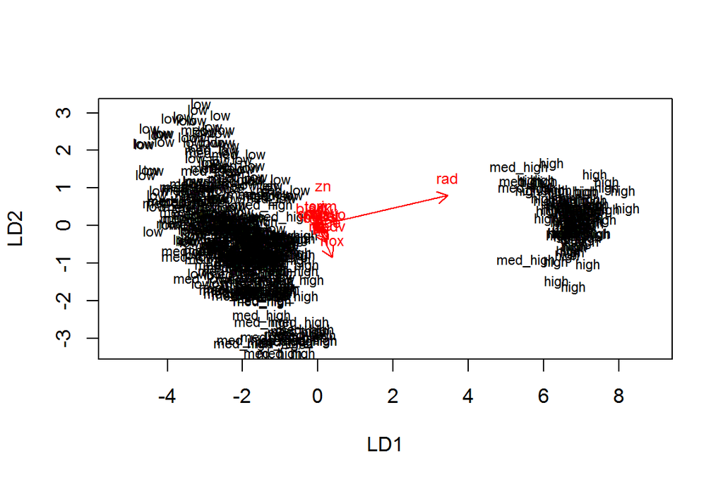

```r
lda.arrows <- function(x, myscale = 1, arrow_heads = 0.1, color = "red", tex = 0.75, choices = c(1,2)){
  heads <- coef(x)
  arrows(x0 = 0, y0 = 0,
         x1 = myscale * heads[,choices[1]],
         y1 = myscale * heads[,choices[2]], col=color, length = arrow_heads)
  text(myscale * heads[,choices], labels = row.names(heads),
       cex = tex, col=color, pos=3)
}
classes <- as.numeric(train$crime)
plot(lda.fit, dimen = 2)
lda.arrows(lda.fit, myscale = 1)
```

Saving the crime categories from the test set and removing them from the test dataset:

```r
testcrime <- test$crime
test <- dplyr::select(test, -crime)
```

Predicting the classes with the LDA model on the test data and cross tabulating the results:

```r
lda.pred <- predict(lda.fit, newdata = test)
table(correct = testcrime, predicted = lda.pred$class)
```

```
##           predicted
## correct    low med_low med_high high
##   low       20      10        4    0
##   med_low    2      12       11    0
##   med_high   0       5       11    2
##   high       0       0        0   25
```

The results seem to be quite good: at least when it comes to low crime rates the model was most of the time able to notice that. Especially when the crime rates were high the model was able to predict it correctly.

Reloading the Boston dataset and standardizing the dataset:

```r
library(MASS)
data(Boston)
sandard_boston <- scale(Boston)
```

Calculating the distances between the observations, and running k-means algorithm.

[figure not shown]

```r
dist_eu <- dist(Boston)
km <-kmeans(dist_eu, centers = 4)
pairs(sandard_boston, col = km$cluster)
```

Now I’ll se what the optimal number of clusters is:

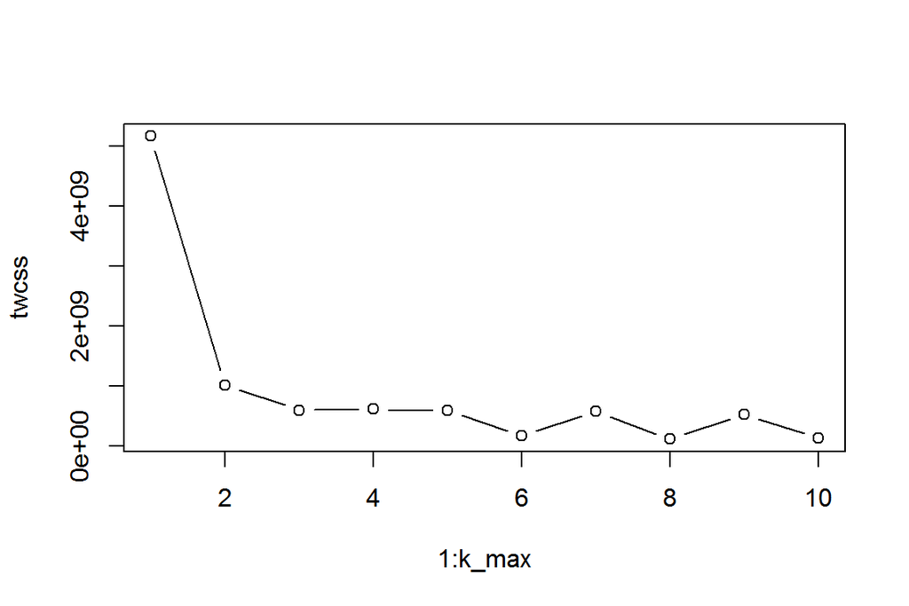

```r
set.seed(123)
k_max <- 10
twcss <- sapply(1:k_max, function(k){kmeans(dist_eu, k)$tot.withinss})
plot(1:k_max, twcss, type='b')
```

It seems that the optimal number of clusters is that of 2.

[figure not shown]

```r
library(ggplot2)
library(GGally)
dist_eu <- dist(Boston)
km <-kmeans(dist_eu, centers = 2)
pairs(sandard_boston, col = km$cluster)
```

Here we see the clusters. I hoped I could somehow make the plot bigger. We can still see how there are two groups in everything: for example in criminality, the amount of people who commit crime is very small.